# Building a hotel reservation cancellation model

## Introduction

The aim of this project is to build a machine learning model that can predict whether or not a hotel room reservation will be cancelled.

### Why might this model be useful?

The hotel industry has developed throughout time, with the majority of reservations made in advance. The use of hotel booking systems makes business more efficient, accurate, and productive for hotels. Cancellation of bookings is currently one of the problems in hotel management. If a booking is cancelled and the hotel is unable to locate a replacement guest to take the room, the hotel will suffer a negative financial impact.

We will use a real hotel booking dataset to build a classification model that will predict whether or not a booking will be canceled with the greatest accuracy possible, as well as gain insights into the customers’ behavior or reasons for canceling their reservation.

## Exploratory Data Analysis

The dataset originates from an open hotel booking demand dataset provided by Antonio et al. (2019). The authors gathered information from two Portuguese hotels. One of the hotels was a resort (H1) and the other was a city hotel (H2). The information was gathered between July 2015 and August 2017. However, because the H2 hotel was in the middle of a soft opening, the authors collected data from September, 2015.

### Loading Data and Packages

The data is available at Kaggle (https://www.kaggle.com/datasets/jessemostipak/hotel-booking-demand).

```r
library(readr)
library(lubridate)
library(tidyverse)
library(corrplot)
library(gtsummary)
library(tidymodels)
library(vip)
library(treeshap)
theme_set(theme_bw())
```

```r
# load data
hotel_booking = read_csv("data/unprocessed/hotel_bookings.csv",
                         show_col_types = FALSE)

# get the dim of the data
dim(hotel_booking)
```

```
## [1] 119390     32
```

```r
# calculate number of records by hotel name and cancellation status
table(hotel_booking$is_canceled, hotel_booking$hotel)
```

```
##
##     City Hotel Resort Hotel
##   0      46228        28938
##   1      33102        11122
```

There are overall 119,390 records and 32 variables. The data has 40,060 records from the Resort Hotel with 28% of them being cancelled, and 79,330 records from City Hotel with 42% of them being cancelled.

### Data cleaning

There are 32 variables in the raw data. The columns “country,” “agent,” and “company” were eliminated because they included missing values and the variables themselves had too many levels to be adequately analyzed. The columns “reservation_status” were removed because it shows the status of the booking. We used 0 to fill in the four missing entries in the “children” column. The dataset has 34,082 duplicated rows, which amount for 28.5% of the total entries. Because the data was created by combining multiple tables from a reservation system, we assumed that the large number of duplicates came from the merging process. As a result, we deleted the duplicated rows.

```r
hotel_booking.clean = hotel_booking %>%
  # remove unimportant columns
  select(-c(country, agent, company)) %>%
  # remove other outcome related variables
  select(-c(reservation_status, reservation_status_date))

# remove duplicated rows
hotel_booking.clean = hotel_booking.clean %>%
  distinct()
```

The meal type “SC” and “Undefined” both represent no meal package, so we could combine them into one group. There are 4 observations without number of children and we assume they do not have children. 98.9% of records do not have any baby, 1% have one baby, and the others range between 2 and 10. We would redefine the baby as a binary variable of with or without baby.

```r
hotel_booking.clean = hotel_booking.clean %>%
  mutate(
    # clean meal
    meal = ifelse(meal %in% c("Undefined", "SC"), "NO", meal),
    # impute missing of children
    children = ifelse(is.na(children), 0, children),
    # clean baby
    babies = ifelse(babies == 0, 0, 1)
  ) %>%
  # convert month from character to number
  unite(date, c(arrival_date_year, arrival_date_month, arrival_date_day_of_month), remove = F) %>%
  mutate(date = ymd(date)) %>%
  mutate(arrival_date_month = month(date)) %>%
  select(-date) %>%
  # convert outcome to factor
  mutate(is_canceled = as.factor(is_canceled))
```

There are two unusual values in the average daily rate (`adr`) – a negative minimum and a very high maximum. We will remove these two outliers. 5 records in which market segment designation is undefined or distribution channel is undefined with a 100% cancellation rate. These records need to be removed from the data.

```r
# clean unusual records
hotel_booking.clean = hotel_booking.clean %>%
  filter(adr >= 0, adr <= 500) %>%
  filter(market_segment!="Undefined", distribution_channel!="Undefined")
```

### Cleaned data description

```r
hotel_booking.clean = write_csv(hotel_booking.clean, file = "data/processed/hotel_booking_cleaned.csv")
```

- `lead_time`: Number of days that elapsed between the entering date of the booking into the PMS and the arrival date
- `arrival_date_year`, `arrival_date_month`, `arrival_date_week_number`, `arrival_date_day_of_month`: Description of arrival date
- `adults`, `children`, `babies`: Description of guests
- `meal`, `required_car_parking_spaces`: Special request

### Data split

The data was split in a 80% training, 20% testing split, stratified by the outcome `is_canceled`.

```r
# data split
set.seed(123)
hotel_booking.clean.split = hotel_booking.clean %>%
  initial_split(prop = 0.8, strata = "is_canceled")
hotel_train = training(hotel_booking.clean.split)
hotel_test = testing(hotel_booking.clean.split)
```

The training data set has about 68,238 observations and the testing data set has just under 17,061 observations.

### Visual EDA

The exploratory data analysis will be based only on the training set. Each observation represents a booking records.

The proportion of cancellations has increased over time since 2016. Reservations for rooms in November and January of the same year were more likely to be honored. More bookings were canceled between April and August.

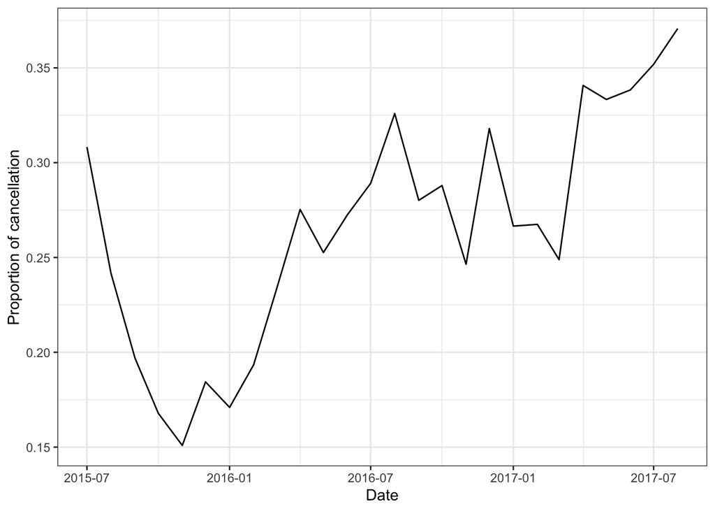

```r
# proportion of cancellation by month of arrival
hotel_train %>%
  unite(date, c(arrival_date_year, arrival_date_month)) %>%
  mutate(date = ym(date)) %>%
  group_by(date) %>%
  summarise(is_canceled_prop = sum(is_canceled==1)/ n()) %>%
  ggplot(aes(x = date, y = is_canceled_prop)) +
  geom_line() +
  labs(x = "Date", y = "Proportion of cancellation")
```

Bookings through travel agents and tour operators (`TA/TO`) are more likely to be canceled than other distribution channels such as corporate, direct, and global distribution system (`gds`). I believe this is due to more individual tourists choosing `TA/TO`, which has a higher possibility of itinerary adjustments. Corporate travelers are those that travel for work and are less likely to have schedule adjustments.

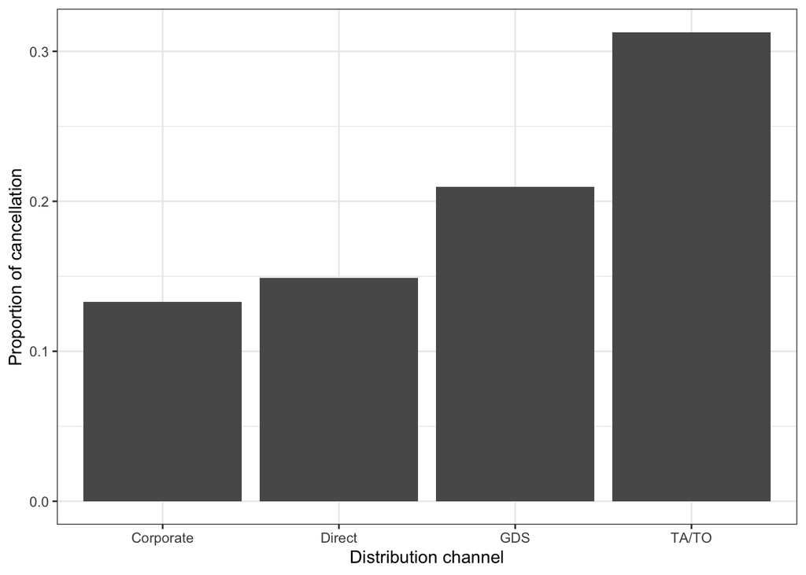

```r
# proportion of cancellation by distribution channel
hotel_train %>%
  group_by(distribution_channel) %>%
  summarise(is_canceled_prop = sum(is_canceled==1)/ n()) %>%
  ggplot(aes(x = distribution_channel, y = is_canceled_prop)) +
  geom_bar(stat = "identity") +
  labs(x = "Distribution channel", y = "Proportion of cancellation")
```

Most of the bookings did not require a deposit. The cancellation rates of both no deposit and required refundable deposit were similar at 26%. Surprisingly, customers who paid a non-refundable deposit have a 94% cancellation rate. Further investigation for customers who chose a non-refund deposit is needed.

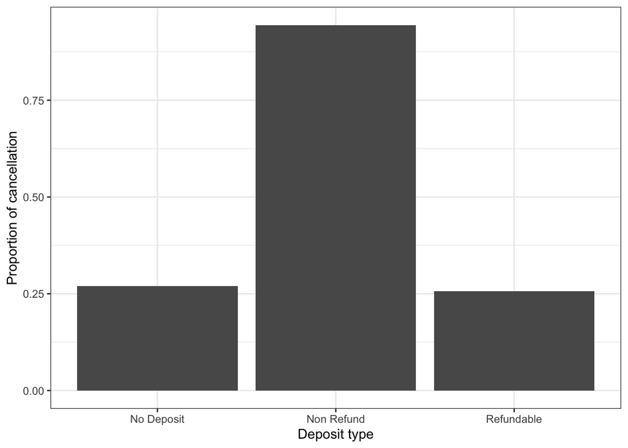

```r
# proportion of cancellation by deposit type
hotel_train %>%
  group_by(deposit_type) %>%
  summarise(is_canceled_prop = sum(is_canceled==1)/ n()) %>%
  ggplot(aes(x = deposit_type, y = is_canceled_prop)) +
  geom_bar(stat = "identity") +
  labs(x = "Deposit type", y = "Proportion of cancellation")
```

In terms of the association between special requests and cancellation booking status, it appears that the greater the number of special requests, the less likely the booking was canceled.

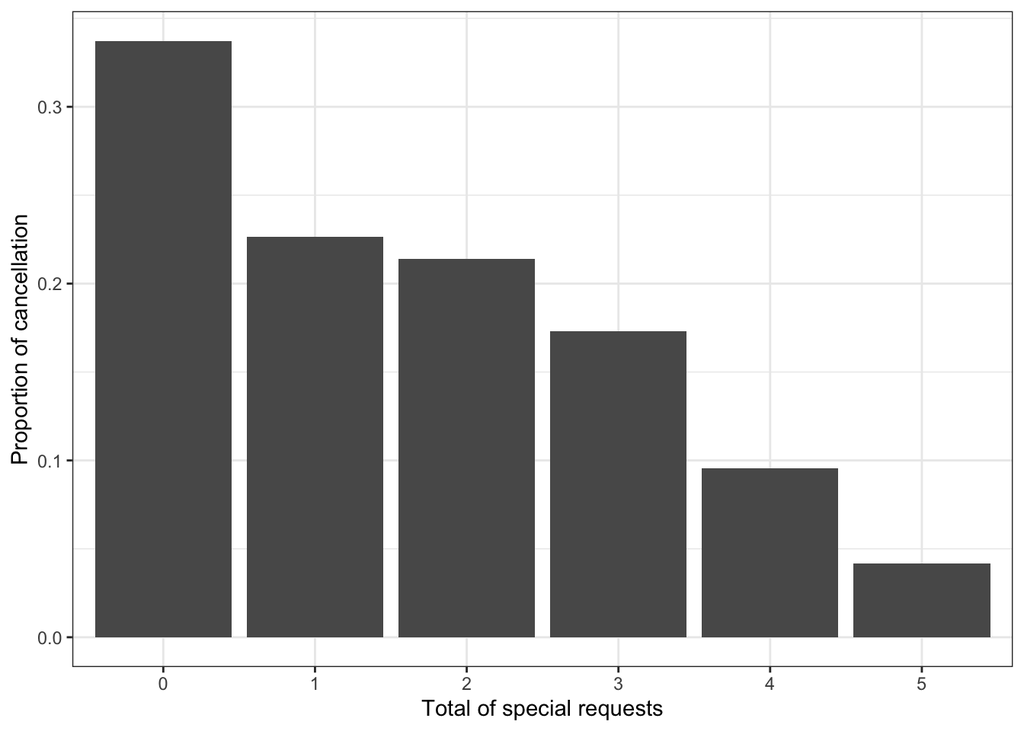

```r
# proportion of cancellation by number of special requests
hotel_train %>%
  mutate(total_of_special_requests = as.factor(total_of_special_requests)) %>%
  group_by(total_of_special_requests) %>%
  summarise(is_canceled_prop = sum(is_canceled==1)/ n()) %>%
  ggplot(aes(x = total_of_special_requests, y = is_canceled_prop)) +
  geom_bar(stat = "identity") +
  labs(x = "Total of special requests", y = "Proportion of cancellation")
```

A strong correlation generally indicates the presence of duplicate features. In the Pearson’s correlation matrix of numerical variables, no feature is highly correlated with another (>|0.7|).

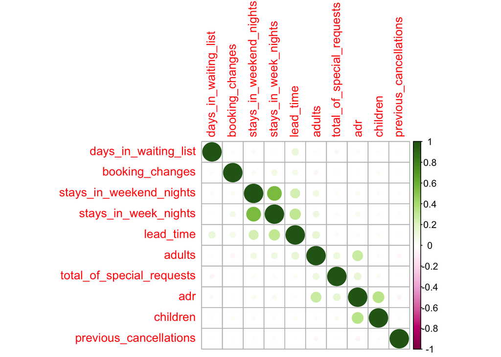

```r
# select numeric variables
hotel_num = hotel_train %>%
  select(previous_cancellations, days_in_waiting_list, booking_changes,
         stays_in_week_nights, stays_in_weekend_nights, lead_time,
         adults, children, total_of_special_requests, adr)
# calculating the correlation between each variable
hotel_cor = cor(hotel_num)
# correlation plot
corrplot(hotel_cor,
         order = 'AOE',
         col = COL2("PiYG"))
```

In the following summary table, we could see that the city hotel has a higher cancellation rate than that of resort hotel, a higher number of days between booking and arrival (`leak_time`) is associated with higher probability of cancellation, a higher average daily rate (`adr`) is associated with higher probability of cancellation, requirement of car spaces (`required_car_parking_spaces`) is associated with lower probability of cancellation, and more total number of special requests (`total_of_special_requests`) is associated with lower probability of cancellation.

```r
tbl_summary(
  hotel_train,
  by = "is_canceled",
  percent = "row"
)
```

| **Characteristic** | **0**, N = 49,272<sup>1</sup> | **1**, N = 18,966<sup>1</sup> |
| --- | --- | --- |
| hotel |  |  |
| City Hotel | 28,815 (69%) | 12,674 (31%) |
| Resort Hotel | 20,457 (76%) | 6,292 (24%) |
| lead_time | 37 (7, 109) | 79 (32, 157) |
| arrival_date_year |  |  |
| 2015 | 8,167 (79%) | 2,116 (21%) |
| 2016 | 24,218 (73%) | 8,887 (27%) |
| 2017 | 16,887 (68%) | 7,963 (32%) |
| arrival_date_month | 7.0 (4.0, 9.0) | 7.0 (4.0, 8.0) |
| arrival_date_week_number | 27 (15, 38) | 27 (17, 35) |
| arrival_date_day_of_month | 16 (8, 23) | 16 (8, 24) |
| stays_in_weekend_nights | 1.00 (0.00, 2.00) | 1.00 (0.00, 2.00) |
| stays_in_week_nights | 2.00 (1.00, 3.00) | 2.00 (1.00, 4.00) |
| adults | 2.00 (2.00, 2.00) | 2.00 (2.00, 2.00) |
| children |  |  |
| 0 | 45,007 (73%) | 16,579 (27%) |
| 1 | 2,550 (69%) | 1,160 (31%) |
| 2 | 1,662 (58%) | 1,211 (42%) |
| 3 | 53 (78%) | 15 (22%) |
| 10 | 0 (0%) | 1 (100%) |
| babies | 596 (82%) | 130 (18%) |
| meal |  |  |
| BB | 38,739 (73%) | 14,248 (27%) |
| FB | 207 (72%) | 80 (28%) |
| HB | 5,189 (73%) | 1,958 (27%) |
| NO | 5,137 (66%) | 2,680 (34%) |
| market_segment |  |  |
| Aviation | 125 (78%) | 36 (22%) |
| Complementary | 475 (87%) | 69 (13%) |
| Corporate | 2,819 (88%) | 400 (12%) |

[output cut: 61 more lines]

<sup>1</sup> n (%); Median (IQR)

## Model Building

### Recipe Building

We establish one primary recipe for all of our models to work with because we will be using the same predictors and response variables. All predictors are centered and scaled once categorical data are transformed to one-hot encoded variables. The reserved room type and the assigned room type have some levels with too few observations, so we could combine them into “other” to simplify the calculation. All the records with at least one required car parking space were not canceled, so we could create a binary variable of with or without the requirement of a car parking space.

```r
# build model recipe
model_recipe = recipe(is_canceled ~ hotel + lead_time + arrival_date_year + arrival_date_month +
                        arrival_date_week_number + arrival_date_day_of_month + stays_in_weekend_nights +
                        stays_in_week_nights + adults + children + babies + meal + market_segment +
                        distribution_channel + is_repeated_guest + previous_cancellations +
                        previous_bookings_not_canceled + reserved_room_type + assigned_room_type +
                        booking_changes + deposit_type + days_in_waiting_list + customer_type +
                        adr + required_car_parking_spaces + total_of_special_requests,
                      data = hotel_train) %>%
  # reduce number of small categorical levels
  step_other(reserved_room_type, threshold = 500) %>%
  step_other(assigned_room_type, threshold = 500) %>%
  step_num2factor(required_car_parking_spaces,
                  transform = function(x) {x = cut(x, breaks = c(-1,0,8), include.lowerest=T); as.numeric(x)},
                  levels = c("No", "Yes")) %>%
  # encode categorical variables
  step_dummy(hotel, meal, market_segment, distribution_channel, required_car_parking_spaces,
             reserved_room_type, assigned_room_type, deposit_type, customer_type,
             one_hot = TRUE) %>%
  # center and scale all predictors
  step_center(all_predictors()) %>%
  step_scale(all_predictors())
```

We are going to use 5-fold cross validation repeated 3 times for model evaluation.

```r
# create cv data
set.seed(123)
cv_folds = vfold_cv(hotel_train, v = 5, repeats = 3, strata = is_canceled)
```

```r
save(hotel_train, cv_folds, model_recipe, file = "data/model/model_data.rda")
```

### Running The Models

We will be trying the following model methods:

- Logistic regression
- Lasso regression
- Decision tree classification
- K-NN classification
- Random forest classification

With our limited computation power, it took several days to build the model and tune the parameters. The scripts of the modeling building are located at `R_scripts` and the fitted results are located at `data/model`.

### Results of our Models

```r
load("data/model/logistic_model.rda")
load("data/model/lasso_model.rda")
load("data/model/knn_model.rda")
load("data/model/decisiontree_model.rda")
load("data/model/rf_model.rda")
```

#### Lasso model

For the lasso, we had one level of penalty. We can see from the graph that the accuracy remained stable when the penalty was less than 0.003 and that a higher penalty caused the accuracy to drop.

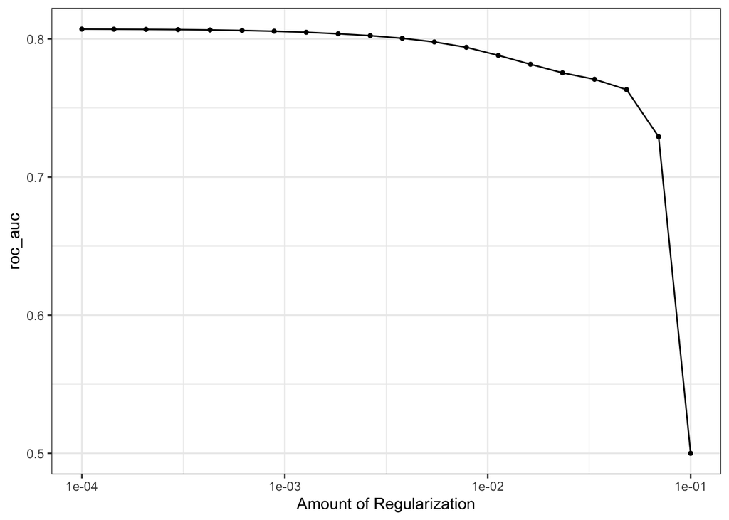

```r
autoplot(lasso_fit)
```

#### Decision Tree Model

For the decision tree, we had two different levels of minimal cost-complexity and tree depth. We can see from the graph that the optimal tree depth was around 15 and penalties greater than 0.0001 caused the accuracy of the decision tree to drop.

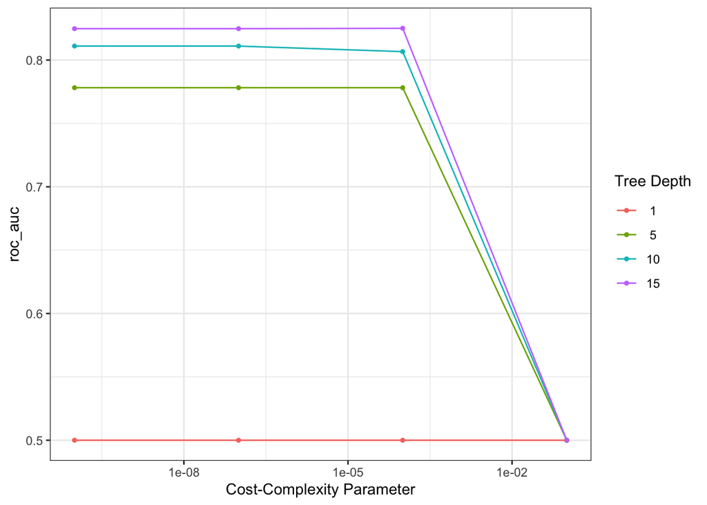

```r
autoplot(decisiontree_fit)
```

### KNN Model

The AUC increases as number of nearest neighbors increases. But the AUC becomes stable when number of nearest neighbors is above 50.

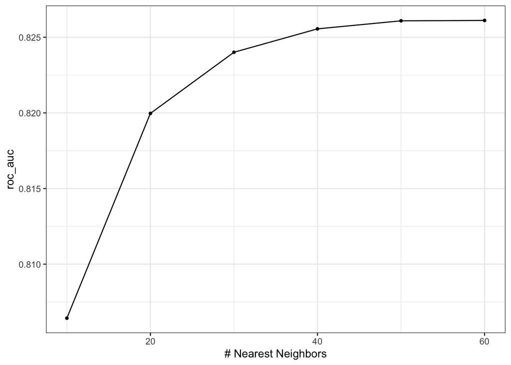

```r
autoplot(knn_fit)
```